# Analiza danych przestrzennych - projekt zaliczeniowy

### 1.2.3 Sprawdzenie normalności rozkładu

```r
shapiro.test(df.kor$unempl_rate)
```

```
##
##  Shapiro-Wilk normality test
##
## data:  df.kor$unempl_rate
## W = 0.94419, p-value = 5.015e-10
```

```r
shapiro.test(df.kor$med_flat_price_per_m_total)
```

```
##
##  Shapiro-Wilk normality test
##
## data:  df.kor$med_flat_price_per_m_total
## W = 0.99307, p-value = 0.1185
```

```r
shapiro.test(df.kor$med_flat_price_per_m_pm)
```

```
##
##  Shapiro-Wilk normality test
##
## data:  df.kor$med_flat_price_per_m_pm
## W = 0.91643, p-value = 9.943e-11
```

```r
shapiro.test(df.kor$med_flat_price_per_m_sm)
```

```
##
##  Shapiro-Wilk normality test
##
## data:  df.kor$med_flat_price_per_m_sm
## W = 0.99167, p-value = 0.05296
```

## 1.2.4. Korelacja Spearmana - prawidłowy wybór dla danych o rozkładzie innym niż normalny i gdy związek między zmiennymi nie jest liniowy.

Pozwala uchwycić zależność monotoniczną między zmiennymi. Korelacja spearmana jest mniej wrażliwa na obserwacje odstające, to też użyta została na danych przed eliminacją obserwacji odstających.

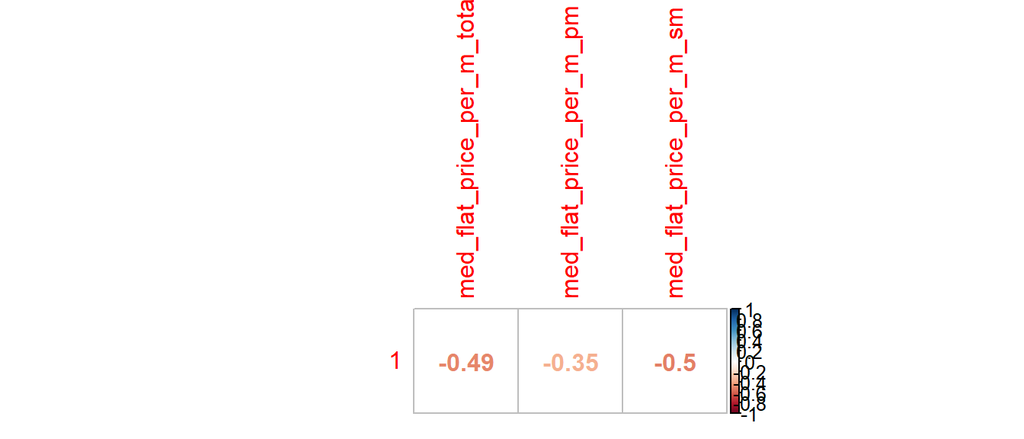

```r
corrs <- cor(x = df.full$unempl_rate,
             y = dplyr::select(df.full, -c(unempl_rate,Nazwa, Kod, kod_pow)),
             use = 'pairwise.complete.obs',
             method = 'spearman')

corrplot(corrs, method = 'number')
```

Widoczna jest słaba negatywna korelacja między stopą bezrobocia, a medianą ceny za metr kwadratowy. Na rynku pierwotnym za zależność jest mniejsza.

# 2. STATYSTYKI STREFOWE

## 2.1 Wczytanie danych NMT PL

```r
DEM.Poland <- getData('alt', country = 'pol', mask = TRUE)
summary(DEM.Poland[])
```

```
##    Min. 1st Qu.  Median    Mean 3rd Qu.    Max.    NA's
##   -11.0    99.0   142.0   168.2   197.0  2079.0  291245
```

```r
 # Funkcja do do pobrania informacji o poligonach
```

```r
summary(DEM.Poland[])
```

```
##    Min. 1st Qu.  Median    Mean 3rd Qu.    Max.    NA's
##   -11.0    99.0   142.0   168.2   197.0  2079.0  291245
```

```r
woj <- read_sf('shp/Województwa.shp')
woj$JPT_KOD_JE <- as.numeric(woj$JPT_KOD_JE)
woj2 <- st_transform(woj, 4326)
```

```r
woj.el.mean <- extract(DEM.Poland, woj, fun = 'mean', na.rm=T, df=T, weights=T)
woj.el.max <- extract(DEM.Poland, woj, fun = max, na.rm=T, df=T)
woj.el.min <- extract(DEM.Poland, woj, fun = min, na.rm=T, df=T)
```

```r
woj.el.stats <- data.frame(woj.el.mean, woj.el.max, woj.el.min) %>%
  rename(el.min = POL_msk_alt.2,
         el.max = POL_msk_alt.1,
         el.mean = POL_msk_alt) %>%
  dplyr::select(-c(ID.1, ID.2))

woj <- woj %>% mutate(ID = row_number())

woj.el.stats.geom <- left_join(x = woj,
                 y = woj.el.stats,
                 by = 'ID')

woj.el.stats.geom %>% dplyr::select(JPT_NAZWA_, el.mean, el.max, el.min)
```

```
## Simple feature collection with 16 features and 4 fields
## geometry type:  MULTIPOLYGON
## dimension:      XY
## bbox:           xmin: 14.12288 ymin: 49.00205 xmax: 24.14578 ymax: 54.83642
## proj4string:    +proj=longlat +ellps=GRS80 +no_defs
## # A tibble: 16 x 5
##    JPT_NAZWA_    el.mean el.max el.min                                  geometry
##    <chr>           <dbl>  <dbl>  <dbl>               <MULTIPOLYGON [arc_degree]>
##  1 śląskie         317.    1280    174 (((18.91685 51.09608, 18.91677 51.0961, ~
##  2 opolskie        204.     733    128 (((17.81203 51.18669, 17.81209 51.1867, ~
##  3 wielkopolskie   101.     265     25 (((16.71447 53.29913, 16.71447 53.2992, ~
##  4 świętokrzysk~   243.     569    125 (((19.7043 50.75239, 19.70443 50.75248, ~
##  5 pomorskie       103.     308    -11 (((17.66483 54.78297, 17.66653 54.78334,~
##  6 kujawsko-pom~    91.5    175     10 (((17.6567 53.57115, 17.65672 53.57115, ~
##  7 podlaskie       145.     283     93 (((21.98108 52.97859, 21.98078 52.97861,~
##  8 zachodniopom~    71.6    235     -6 (((14.81157 54.04037, 14.89525 54.0557, ~
##  9 dolnośląskie    246.    1421     65 (((15.10534 51.4273, 15.1054 51.42732, 1~
## 10 podkarpackie    307.    1251    101 (((22.03538 50.80675, 22.0355 50.80681, ~
## 11 małopolskie     420.    2079    157 (((19.9723 50.51625, 19.97227 50.51633, ~
## 12 warmińsko-ma~   126.     298     -5 (((21.55932 54.3225, 21.55939 54.3225, 2~
## 13 łódzkie         169.     373     23 (((19.99385 51.18395, 19.9941 51.18395, ~
## 14 mazowieckie     127.     389     50 (((21.98576 52.97722, 21.98587 52.97708,~
## 15 lubelskie       193.     367    104 (((21.61554 51.61756, 21.62194 51.62192,~
## 16 lubuskie         81.8    219      8 (((15.10534 51.4273, 15.10521 51.42727, ~
```

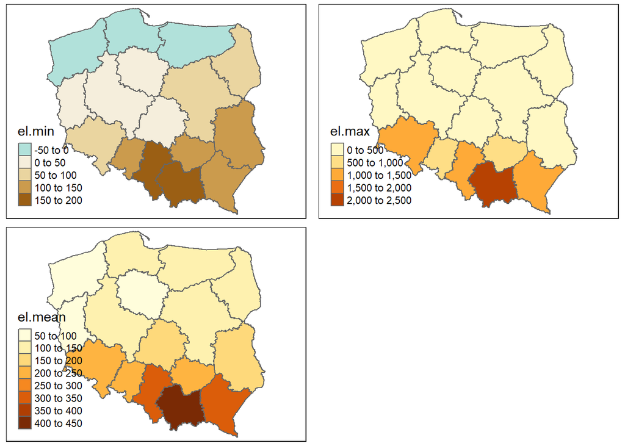

```r
basemap <- tm_shape(woj.el.stats.geom) + tm_borders()

map.min <- basemap + tm_fill(col = 'el.min', palette = '-BrBG')
map.mean <- basemap + tm_fill(col = 'el.mean',  palette = 'YlOrBr')
map.max <- basemap + tm_fill(col = 'el.max', palette = 'YlOrBr')

tmap_arrange(map.min, map.max, map.mean)
```

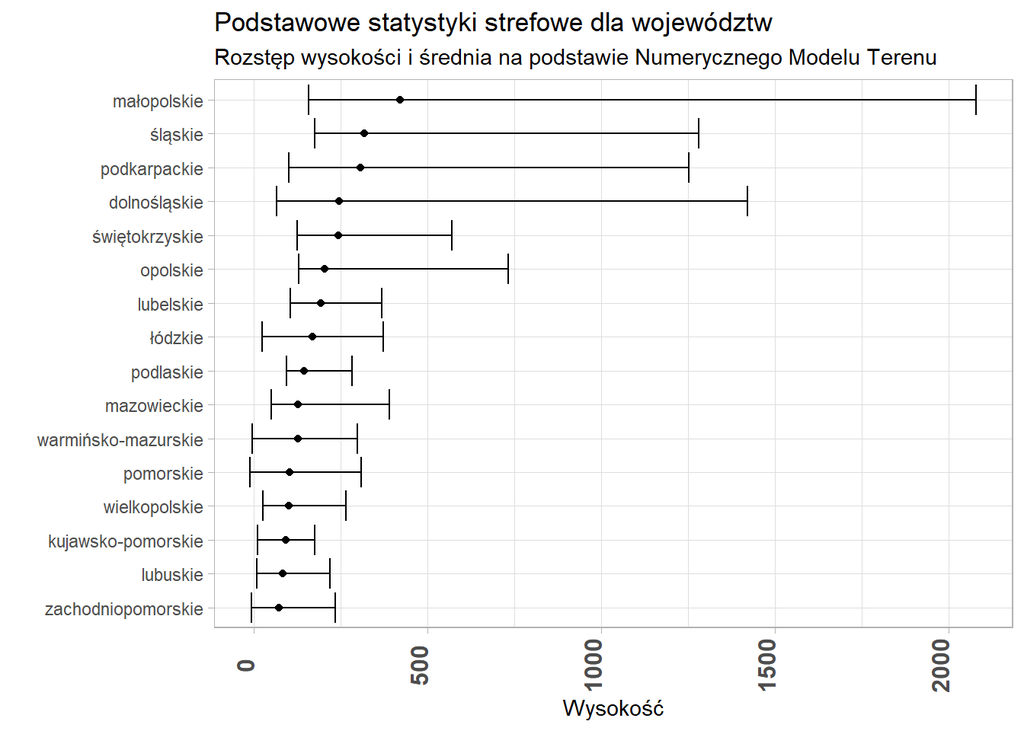

```r
ggplot(woj.el.stats.geom, aes(x=reorder(JPT_NAZWA_, el.mean, FUN = median))) +
  geom_errorbar(aes(ymin=el.min, ymax=el.max)) +
  geom_point(aes(y=el.mean)) +
  labs(title='Podstawowe statystyki strefowe dla województw',
       subtitle='Rozstęp wysokości i średnia na podstawie Numerycznego Modelu Terenu',
       x='', y='Wysokość') +
  theme_light() +
  theme(axis.text.x = element_text(angle = 90, face = 'bold', size=12, vjust=0)) +
  coord_flip()
```

W dolnośląskim średnia jest niższa niż w śląskim i podkarpackim, znacznie bliżej mu pod tym względem do świętokrzystkiego, jednak max jest większy od dwóch wspomnianych województw. Rejon śnieżki jest znacznie wyżej położony niż Beskid Śląski, czy Bieszczady, jednak dolnośląskie obejmuje również nieco większe obszary terenów niżej położonych.

```r
powiaty <- read_sf('shp/Powiaty.shp')
```

```r
powiaty$JPT_KOD_JE <- as.numeric(powiaty$JPT_KOD_JE)
powiaty2 <- st_transform(powiaty, 4326)
powiaty.ra <- rasterize(powiaty2,
                               DEM.Poland,
                               field = 'JPT_KOD_JE',
                               fun = max)
powiaty.zone <- zonal(DEM.Poland, powiaty.ra, fun = max)
#powiaty3 <- left_join(powiaty2, as.data.frame(powiaty.zone), by=c('JPT_KOD_JE'='zone'))
```

```r
powiaty3 <- left_join(powiaty2, as.data.frame(powiaty.zone), by=c('JPT_KOD_JE'='zone'))
```

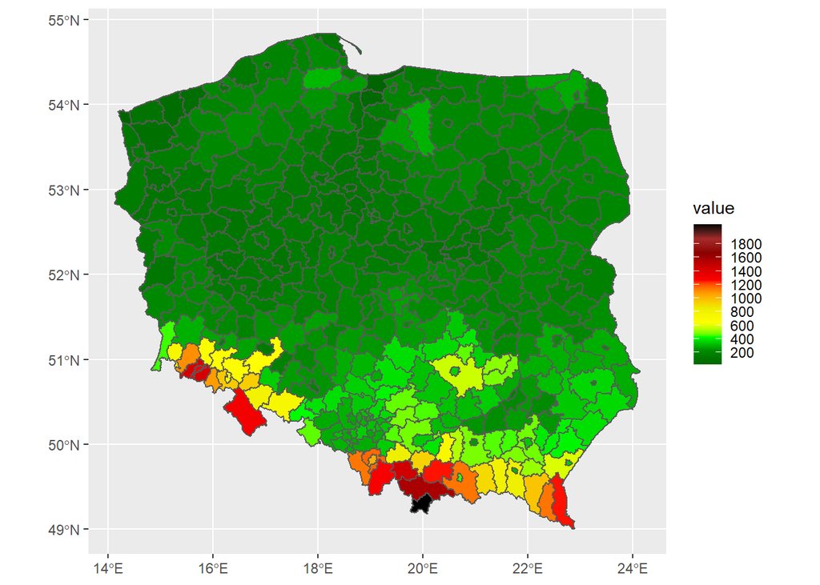

```r
ggplot()+geom_sf(data = powiaty3, aes(fill=value)) +
  scale_fill_gradientn(colours = c("darkgreen", "green4", "green", "yellow", "yellow2", "orange", "red", "red3", "red4", "brown", "black"),
                       breaks = c(0, 200, 400,600, 800, 1000, 1200, 1400, 1600, 1800, 2100))
```